# 7.2

Joseph Elikishvili

December 11, 2017

### 7.2

#### Chapter 7 talks about non linear regressions. It goes over several models. Specifically MARS, SVM and K-NN. Exercise 7.2 goes over evaluating different models and comparing the results to better understand how to chose the appropriate model for a specific situation.

We will preload the necessary libraries and generate the training and test data, then try the data on KNN, MARS and SVM and finally we will compare the results.

```r
library(mlbench)
set.seed(200)
trainingData <- mlbench.friedman1(200, sd = 1)
## We convert the 'x' data from a matrix to a data frame
## One reason is that this will give the columns names.
trainingData$x <- data.frame(trainingData$x)
## Look at the data using
#featurePlot(trainingData$x, trainingData$y)
## or other methods.
```

```r
 ## This creates a list with a vector 'y' and a matrix
 ## of predictors 'x'. Also simulate a large test set to
 ## estimate the true error rate with good precision:
 testData <- mlbench.friedman1(5000, sd = 1)
 testData$x <- data.frame(testData$x)
```

### KNN

First we will use KNN model and view the results.

```r
library(caret)
knnModel <- train(x = trainingData$x, y = trainingData$y, method = "knn", preProc = c("center", "scale"), tuneLength = 10)
knnModel
```

```
## k-Nearest Neighbors
##
## 200 samples
##  10 predictor
##
## Pre-processing: centered (10), scaled (10)
## Resampling: Bootstrapped (25 reps)
## Summary of sample sizes: 200, 200, 200, 200, 200, 200, ...
## Resampling results across tuning parameters:
##
##   k   RMSE      Rsquared   MAE
##    5  3.565620  0.4887976  2.886629
##    7  3.422420  0.5300524  2.752964
##    9  3.368072  0.5536927  2.715310
##   11  3.323010  0.5779056  2.669375
##   13  3.275835  0.6030846  2.628663
##   15  3.261864  0.6163510  2.621192
##   17  3.261973  0.6267032  2.616956
##   19  3.286299  0.6281075  2.640585
##   21  3.280950  0.6390386  2.643807
##   23  3.292397  0.6440392  2.656080
##
## RMSE was used to select the optimal model using  the smallest value.
## The final value used for the model was k = 15.
```

Next we will use the trained model to make a prediction and review the RMSE

```r
knnPred <- predict(knnModel, newdata = testData$x)
## The function 'postResample' can be used to get the test set
## perforamnce values
postResample(pred = knnPred, obs = testData$y)
```

```
##      RMSE  Rsquared       MAE
## 3.1750657 0.6785946 2.5443169
```

We get RMSE = 3.17

### MARS

Next we will take a look at MARS model

```r
set.seed(101)
mars_grid = expand.grid(degree =1:2, nprune=seq(2,14,by=2))
marsTune = train(x= trainingData$x, y=trainingData$y, method='earth', tuneGrid=mars_grid, trControl = trainControl(method = "cv"))
marsTune
```

```
## Multivariate Adaptive Regression Spline
##
## 200 samples
##  10 predictor
##
## No pre-processing
## Resampling: Cross-Validated (10 fold)
## Summary of sample sizes: 180, 180, 180, 180, 180, 180, ...
## Resampling results across tuning parameters:
##
##   degree  nprune  RMSE      Rsquared   MAE
##   1        2      4.417014  0.2350732  3.656244
##   1        4      2.606487  0.7293074  2.069700
##   1        6      2.192319  0.8094378  1.742533
##   1        8      1.700573  0.8889867  1.313446
##   1       10      1.640852  0.8967593  1.277871
##   1       12      1.641261  0.8950167  1.297462
##   1       14      1.642807  0.8964578  1.287479
##   2        2      4.417014  0.2350732  3.656244
##   2        4      2.606487  0.7293074  2.069700
##   2        6      2.218192  0.8021446  1.729223
##   2        8      1.750853  0.8789636  1.370531
##   2       10      1.449480  0.9177568  1.111537
##   2       12      1.316041  0.9299167  1.026115
##   2       14      1.321235  0.9300051  1.048692
##
## RMSE was used to select the optimal model using  the smallest value.
## The final values used for the model were nprune = 12 and degree = 2.
```

We will review the Variable importance

```r
#Variable Importance
varImp(marsTune)
```

```
## earth variable importance
##
##     Overall
## X1   100.00
## X4    85.05
## X2    69.03
## X5    48.88
## X3    39.40
## X10    0.00
## X6     0.00
## X9     0.00
## X7     0.00
## X8     0.00
```

It appears MARS is only using x1-x5 to make a prediction.

Next we will make the prediction using MARS and review the results.

```r
mars_pred = predict (marsTune, testData$x)
postResample(pred = mars_pred, obs = testData$y)
```

```
##      RMSE  Rsquared       MAE
## 1.2803060 0.9335241 1.0168673
```

We get RMSE = 1.28 which is a definite improvement from KNN

### SVM

Next we will use SVM model

```r
set.seed(102)
svmTune = train(x= trainingData$x, y=trainingData$y, method='svmRadial', tuneLength = 14, trControl = trainControl(method = "cv"))
svmTune$finalModel
```

```
## Support Vector Machine object of class "ksvm"
##
## SV type: eps-svr  (regression)
##  parameter : epsilon = 0.1  cost C = 4
##
## Gaussian Radial Basis kernel function.
##  Hyperparameter : sigma =  1
##
## Number of Support Vectors : 186
##
## Objective Function Value : -82.2151
## Training error : 0.009563
```

Lets review the variable importance

```r
varImp(svmTune)
```

```
## loess r-squared variable importance
##
##      Overall
## X4  100.0000
## X1   95.5047
## X2   89.6186
## X5   45.2170
## X3   29.9330
## X9    6.3299
## X10   5.5182
## X8    3.2527
## X6    0.8884
## X7    0.0000
```

Lets review the results

```r
svmPred <- predict(svmTune, newdata = testData$x)
postResample(pred = svmPred, obs = testData$y)
```

```
##      RMSE  Rsquared       MAE
## 4.8618512 0.2038278 3.9582613
```

We get RMSE = 4.86

### Conclusion

We conclude that MARS is the most accurate of the 3 models in this particular case. It resulted in the lowest RMSE of 1.28

### 7.5. Exercise 6.3 describes data for a chemical manufacturing process. Use the same data imputation, data splitting, and pre-processing steps as before and train several nonlinear regression models.

We will import imputation and data splitting code from 6.3 below.

```r
library(AppliedPredictiveModeling)
library(caret)

data(ChemicalManufacturingProcess)
df = ChemicalManufacturingProcess
#summary(df)

library(missForest)
df_imp1 = missForest(df)
```

```
##   missForest iteration 1 in progress...done!
##   missForest iteration 2 in progress...done!
##   missForest iteration 3 in progress...done!
##   missForest iteration 4 in progress...done!
```

```r
df_imp = df_imp1$ximp

data = df_imp[,2:58]
target = df_imp[,1]

training = createDataPartition( target, p=0.75 )
predictor_training = data[training$Resample1,]
target_training = target[training$Resample]

predictor_testing = data[-training$Resample1,]
target_testing = target[-training$Resample1]
```

### KNN

We will start with KNN model and will measure the performance of the model.

```r
knnModel_75 <- train(x = predictor_training, y = target_training, method = "knn", preProc = c("center", "scale"), tuneLength = 10)
knnModel_75
```

```
## k-Nearest Neighbors
##
## 132 samples
##  57 predictor
##
## Pre-processing: centered (57), scaled (57)
## Resampling: Bootstrapped (25 reps)
## Summary of sample sizes: 132, 132, 132, 132, 132, 132, ...
## Resampling results across tuning parameters:
##
##   k   RMSE      Rsquared   MAE
##    5  1.384146  0.3768763  1.078726
##    7  1.387710  0.3669445  1.109488
##    9  1.413321  0.3455230  1.141322
##   11  1.429472  0.3305082  1.160532
##   13  1.440057  0.3194528  1.172922
##   15  1.444468  0.3156153  1.177875
##   17  1.451980  0.3073148  1.189475
##   19  1.454195  0.3029005  1.191154
##   21  1.449979  0.3093282  1.187930
##   23  1.448196  0.3127738  1.188744
##
## RMSE was used to select the optimal model using  the smallest value.
## The final value used for the model was k = 5.
```

Looks like we get the best RMSE metrics with n=5. We will use the model to make the prediction.

```r
knnPred_75 <- predict(knnModel_75, newdata = predictor_testing)
postResample(pred = knnPred_75, obs = target_testing)
```

```
##      RMSE  Rsquared       MAE
## 1.5495677 0.4973659 1.2286818
```

#### Next we will use MARS model and measure the predictive performance.

```r
mars_grid = expand.grid(degree =1:2, nprune=seq(2,14,by=2))
marsTune_75 = train(x = predictor_training, y = target_training, method='earth', tuneGrid=mars_grid, trControl = trainControl(method = "cv"))
marsTune_75
```

```
## Multivariate Adaptive Regression Spline
##
## 132 samples
##  57 predictor
##
## No pre-processing
## Resampling: Cross-Validated (10 fold)
## Summary of sample sizes: 120, 119, 119, 119, 118, 118, ...
## Resampling results across tuning parameters:
##
##   degree  nprune  RMSE      Rsquared   MAE
##   1        2      1.388833  0.4162738  1.0937821
##   1        4      1.168918  0.5991866  0.9458691
##   1        6      1.265335  0.5485218  1.0050530
##   1        8      1.336531  0.4986164  1.0847822
##   1       10      1.217123  0.5945703  0.9454200
##   1       12      1.209208  0.5854100  0.9321785
##   1       14      1.198510  0.5961953  0.9504527
##   2        2      1.389164  0.4160174  1.0940570
##   2        4      1.192578  0.5690754  0.9631306
##   2        6      1.231714  0.5424268  0.9690872
##   2        8      1.233921  0.5448525  0.9706489
##   2       10      1.226324  0.5563709  0.9701000
##   2       12      1.281809  0.5263668  0.9913089
##   2       14      1.246238  0.5583326  0.9787434
##
## RMSE was used to select the optimal model using  the smallest value.
## The final values used for the model were nprune = 4 and degree = 1.
```

Next we will make the prediction using MARS and review the results.

```r
marspred_75 = predict (marsTune_75, predictor_testing)
postResample(pred = marspred_75, obs = target_testing)
```

```
##      RMSE  Rsquared       MAE
## 1.1724850 0.7060344 0.9081153
```

We have RMSE of 1.17 which is a slight improvement over KNN model.

#### Next we will use SVM model to make the prediction on the data set.

```r
svmTune_75 = train(x = predictor_training, y = target_training, method='svmRadial', tuneLength = 14, trControl = trainControl(method = "cv"))
svmTune_75
```

```
## Support Vector Machines with Radial Basis Function Kernel
##
## 132 samples
##  57 predictor
##
## No pre-processing
## Resampling: Cross-Validated (10 fold)
## Summary of sample sizes: 118, 119, 120, 119, 117, 119, ...
## Resampling results across tuning parameters:
##
##   C        RMSE      Rsquared    MAE
##      0.25  1.749680  0.04943935  1.430692
##      0.50  1.746559  0.05023220  1.432773
##      1.00  1.743879  0.05216393  1.436458
##      2.00  1.744816  0.05261132  1.443579
##      4.00  1.744883  0.05257954  1.442838
##      8.00  1.744883  0.05257954  1.442838
##     16.00  1.744883  0.05257954  1.442838
##     32.00  1.744883  0.05257954  1.442838
##     64.00  1.744883  0.05257954  1.442838
##    128.00  1.744883  0.05257954  1.442838
##    256.00  1.744883  0.05257954  1.442838
##    512.00  1.744883  0.05257954  1.442838
##   1024.00  1.744883  0.05257954  1.442838
##   2048.00  1.744883  0.05257954  1.442838
##
## Tuning parameter 'sigma' was held constant at a value of 0.01305284
## RMSE was used to select the optimal model using  the smallest value.
## The final values used for the model were sigma = 0.01305284 and C = 1.
```

Lets review the results

```r
svmPred_75 <- predict(svmTune_75, newdata = predictor_testing)
postResample(pred = svmPred_75, obs = target_testing)
```

```
##       RMSE   Rsquared        MAE
## 2.08911441 0.03096715 1.65214815
```

### A. Which nonlinear regression model gives the optimal resampling and test set performance?

Out of 3 non linear models we used, MARS has the best accuracy with RMSE of 1.17

### B. Which predictors are most important in the optimal nonlinear regression model? Do either the biological or process variables dominate the list? How do the top ten important predictors compare to the top ten predictors from the optimal linear model?

Lets review predictor importance of MARS and KNN models as they have the best RSME scores.

```r
#plot(varImp(knnModel))
```

```r
#plot(varImp(marsTune))
```

#### C. Explore the relationships between the top predictors and the response for the predictors that are unique to the optimal nonlinear regression model. Do these plots reveal intuition about the biological or process predictors and their relationship with yield?

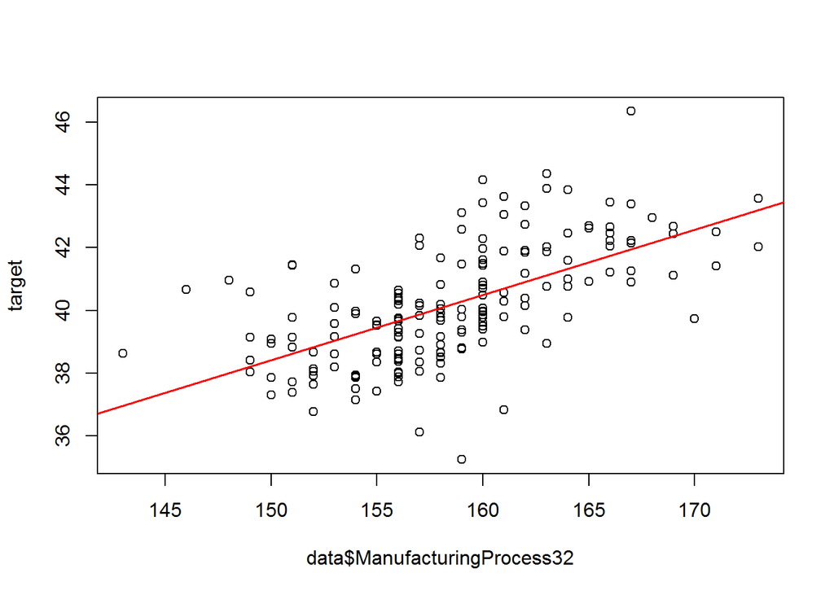

```r
plot(data$ManufacturingProcess32, target)
abline(lm(target~data$ManufacturingProcess32),col="red",lwd=1.5)
```

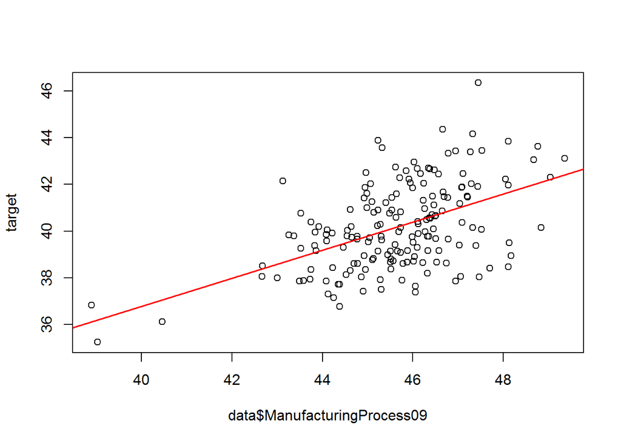

```r
plot(data$ManufacturingProcess09, target)
abline(lm(target~data$ManufacturingProcess09),col="red",lwd=1.5)
```

Both predictors have positive corelation. Lets check the exact corelation

```r
cor(data$ManufacturingProcess32, target)
```

```
## [1] 0.6083321
```

```r
cor(data$ManufacturingProcess09, target)
```

```
## [1] 0.5034705
```